# Introduction to the scimetr package

UDC Ranking’s Group

scimetr 1.2.0: 2026-03-01

```r
library(scimetr)
```

This vignette illustrates the use of the [`scimetr`](https://rubenfcasal.github.io/scimetr/) package for performing bibliometric analyses using datasets exported from Web of Science, highlighting the main workflows and functionalities. The package provides tools for scientometric and bibliometric research, including routines to import bibliographic records from [*Clarivate Analytics Web of Science*](https://www.webofscience.com/) (WoS) and conduct bibliometric analyses.

A list of other useful R packages for this type of analysis is available [here](https://rubenfcasal.github.io/scimetr/articles/docs/R_packages.html).

# Installation

Since the package is not yet available on CRAN, you need to install the development version from the GitHub repository rubenfcasal/scimetr:

```r
# install.packages("remotes")
remotes::install_github("rubenfcasal/scimetr")
```

Alternatively, Windows users may install the corresponding *scimetr_X.Y.Z.zip* file in the [releases section](https://github.com/rubenfcasal/scimetr/releases/latest) of the github repository. It is recommended to first install its dependencies:

```r
# Dependencies
install.packages(c("dplyr", "tidyr", "stringr", "ggplot2", "scales", "rlang"))
# Last released version
install.packages("https://github.com/rubenfcasal/scimetr/releases/download/v1.1.0/scimetr_1.1.0.zip", repos = NULL)
```

Once the package is installed, it can be loaded as usual.

# Bibliographic data

We will focus exclusively on importing publication data from [WoS](https://www.webofscience.com/) in text format. First, you need to download the corresponding files from the WoS website, for example, by following the steps described [here](https://rubenfcasal.github.io/scimetr/articles/WoS_export.html).

## Loading WoS data from a directory

WoS files (which by default are limited to 500 records each) can be automatically loaded from a subdirectory:

```r
dir("UDC_2018-2023 (01-02-2024)", pattern = "*.txt")
```

```
##  [1] "savedrecs01.txt" "savedrecs02.txt" "savedrecs03.txt" "savedrecs04.txt"
##  [5] "savedrecs05.txt" "savedrecs06.txt" "savedrecs07.txt" "savedrecs08.txt"
##  [9] "savedrecs09.txt" "savedrecs10.txt"
```

To combine the files into a `data.frame`, the `import_wos()` function is used:

```r
wos.data <- import_wos("UDC_2018-2023 (01-02-2024)")
```

Next, the database must be created using the `db_bib()` function, as shown later.

## Example data

The package includes the example dataset `wosdf` (obtained using the `import_wos()` function), corresponding to a WoS search by the Affiliation field of *Universidade da Coruña (UDC)* (Affiliation: OG = Universidade da Coruna) in the research area `"Mathematics"` during the years 2018–2023.

All data tables have an associated `variable.labels` attribute with the variable labels. These will be displayed below the variable names when viewed in RStudio (e.g. `View(wosdf)`).

```r
wos.labels <- attr(wosdf, "variable.labels")
knitr::kable(head(data.frame(wos.labels)),
  col.names = c("Variable", "Label")
)
```

| Variable | Label |
| --- | --- |
| PT | Publication Type |
| AU | Author |
| AF | Author Full Name |
| TI | Article Title |
| SO | Source Title |
| SE | Book Series Title |

…

A full list of the variables used in the database tables is shown in the final section *Variable list* of this document.

# Bibliographic database

`scimetr` uses lists with `data.frame` components as relational databases.

To create the [bibliographic database](https://en.wikipedia.org/wiki/Bibliographic_database), use the `db_bib()` function (the result is a `wos.db`-class S3 object):

```r
db <- db_bib(wosdf, label = "Mathematics_UDC_2018-2023")
names(db)
```

[output not shown]

## Summaries

You can generate either global summaries or yearly summaries of your database.

### Global summary

The `summary()` method of a bibliographic database `(summary.wos.db()`), provides an overview of the entire database, including total documents, authors, journals, citations, and other aggregated statistics.

```r
res1 <- summary(db)
options(digits = 5)
res1
```

```
## Number of documents: 293
## Authors: 504
## Period: 2018 - 2023
##
## Document types:
##                            Documents
## Article                          254
## Article; Early Access              1
## Article; Proceedings Paper         2
## Correction                         7
## Editorial Material                21
## Review                             8
##
## Number of authors per document:
##    Min. 1st Qu.  Median    Mean 3rd Qu.    Max.
##    1.00    3.00    3.00    3.63    4.00   13.00
##
## Number of documents per author:
##    Min. 1st Qu.  Median    Mean 3rd Qu.    Max.
##    1.00    1.00    1.00    2.11    2.00   23.00
##
## Number of times cited:
##    Min. 1st Qu.  Median    Mean 3rd Qu.    Max.
##    0.00    1.00    3.00    5.87    7.00  123.00
##
## Indexes:
##  H  G
## 19 27
##
## Status:
## Highly Cited   Hot Papers
##            1            0
##
## Top Categories:
##                                                  Documents
## Mathematics, Applied                                   133
## Mathematics                                             96
## Statistics & Probability                                84
## Mathematics, Interdisciplinary Applications             55
## Computer Science, Interdisciplinary Applications        30
```

[output cut: 35 more lines]

```
## Top Countries:
##           Documents
## Spain           293
## France           20
## UK               18
## USA              17
## Italy            13
## Chile             9
## Ecuador           9
## Portugal          8
## Argentina         6
## Uruguay           6
## Others           46
##
## International colaboration documents (Spain): 134
```

### Yearly summary

The `summary_year()` method breaks down the summary *by year*, showing trends over time in publications, citations, and other key metrics.

```r
res2 <- summary_year(db)
res2
```

```
## Annual Scientific Production:
##      Documents
## 2018        40
## 2019        61
## 2020        46
## 2021        51
## 2022        45
## 2023        50
##
## Annual Authors per Document:
##    PY   Mean Median
##  2018 3.3250    3.5
##  2019 3.5902    3.0
##  2020 3.8696    3.0
##  2021 3.5098    3.0
##  2022 3.8444    3.0
##  2023 3.6600    3.0
##
## Annual Times Cited:
##    PY Cites   Mean Median
##  2018   364 9.1000    5.0
##  2019   538 8.8197    5.0
##  2020   306 6.6522    3.0
##  2021   206 4.0392    3.0
##  2022   186 4.1333    2.0
##  2023   120 2.4000    1.5
##
## Status:
##    PY Highly Cited Hot Paper
##  2018            0         0
##  2019            1         0
##  2020            0         0
##  2021            0         0
##  2022            0         0
##  2023            0         0
```

## Visualizations

The [`ggplot2`](https://ggplot2.tidyverse.org) package is used to create a wide variety of visualizations from the database.  
There are three main types of plots you can create:

- Database plots (`plot(db)`).
- Summary plots (`plot(summary(db)`).
- Yearly summary plots (`plot(summary_year(db))`).

Note: All `plot()` methods invisible return a list with the generated `ggplot2` objects (use `plot = FALSE` to avoid plotting).

### Database plots

The `plot()` method of a bibliographic database (`plot.wos.db()`) provides a general visualization of its contents.

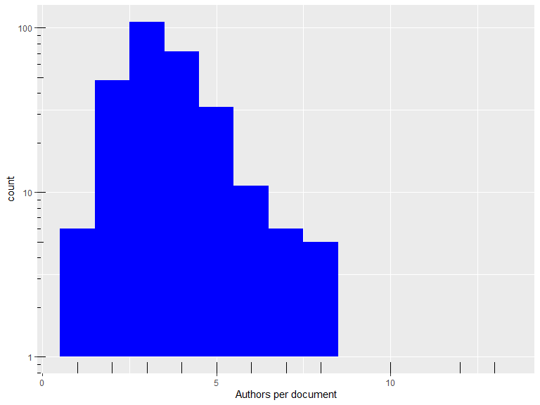

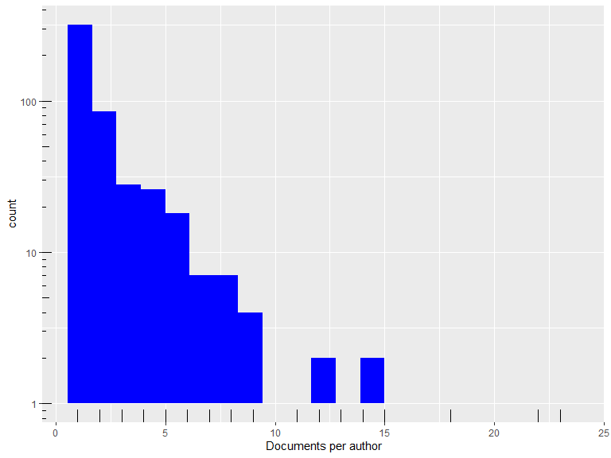

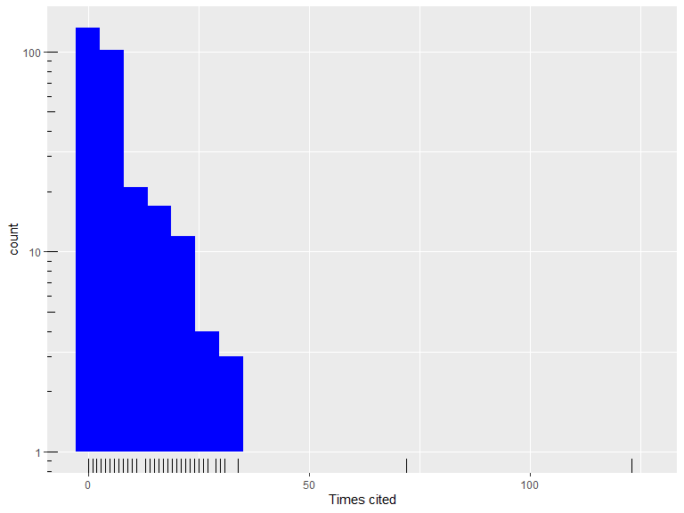

```r
plot(db)
```

### Summary plots

The plot method of a summary result (`plot.summary.wos.db()`) visualizes the results generating different types of plots: standard bar, line plots or Pie charts (`pie = TRUE`).

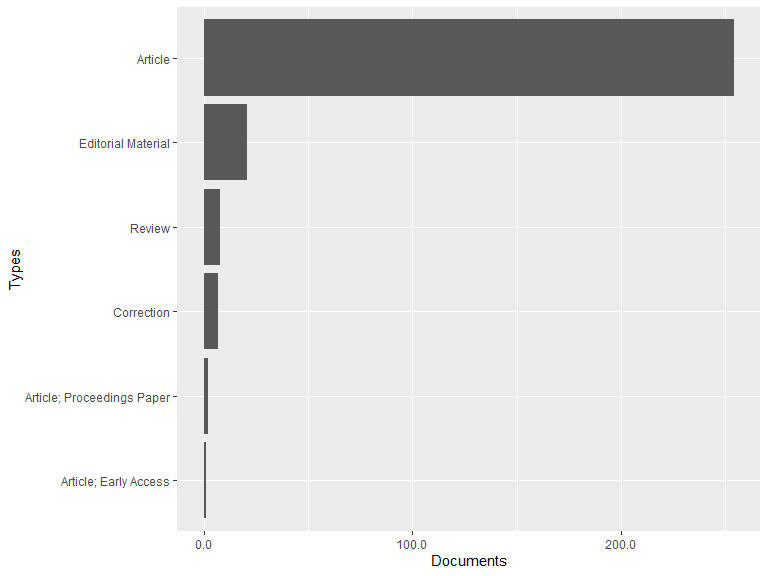

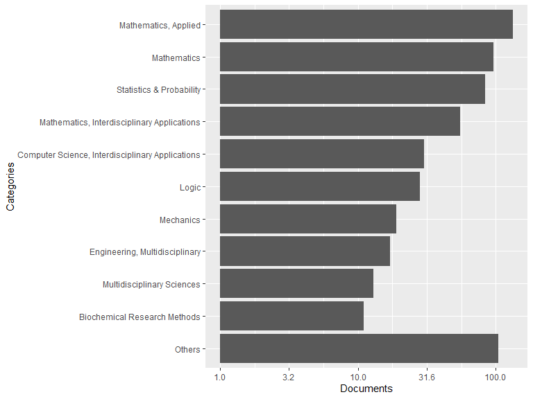

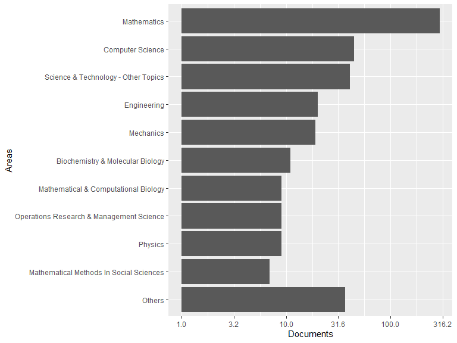

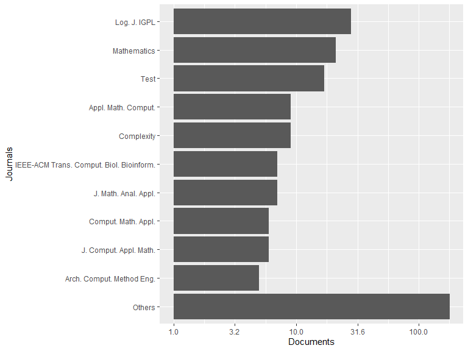

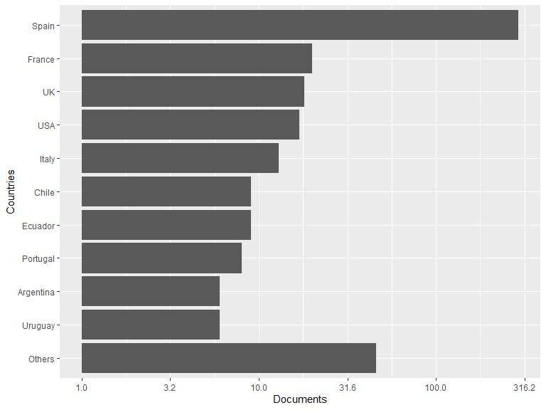

```r
plot(res1)
```

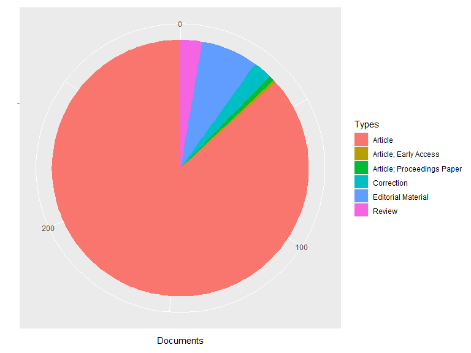

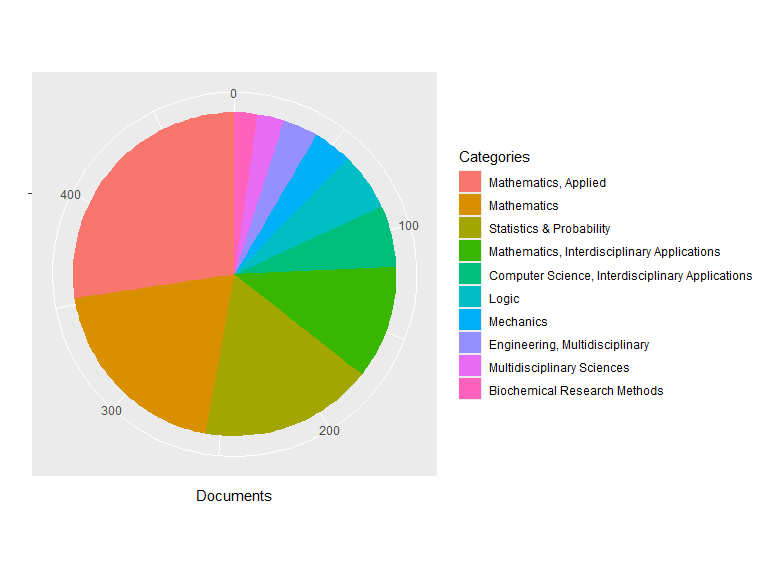

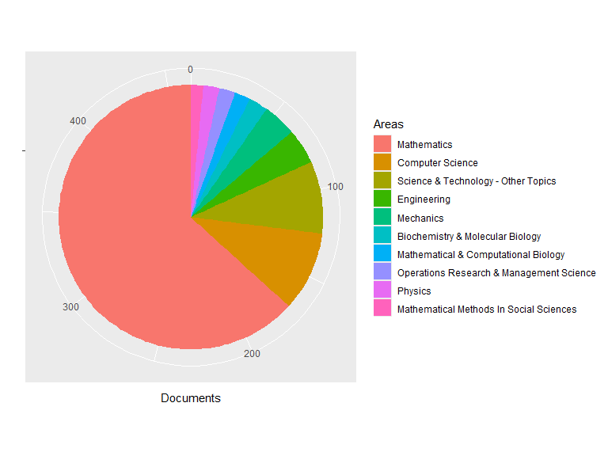

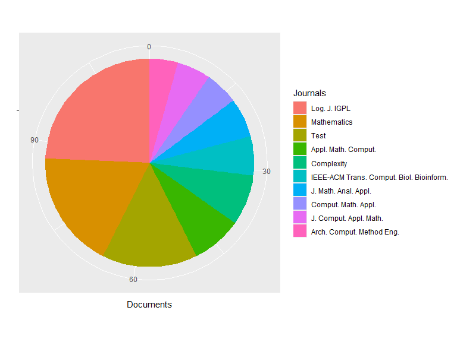

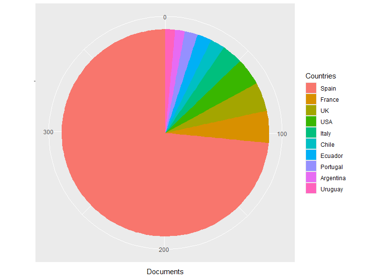

```r
plot(res1, pie = TRUE)
```

### Yearly summary plots

The `plot()` method of a yearly summary (`plot.summary.year()`) visualizes the results generating different types of plots: standard bar and line plots for trends over time, or boxplots (`boxplot = TRUE`), to show variability within each year.

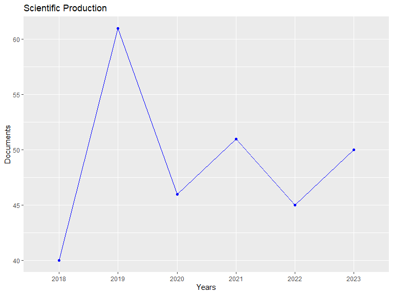

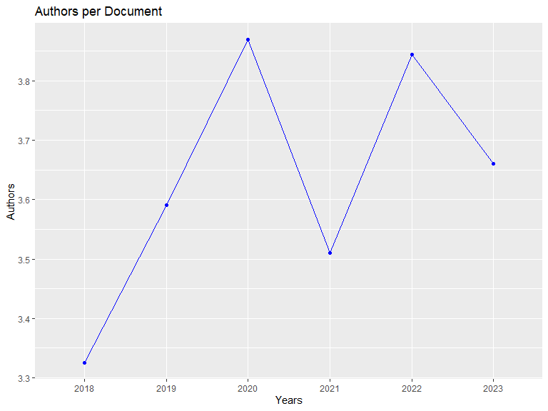

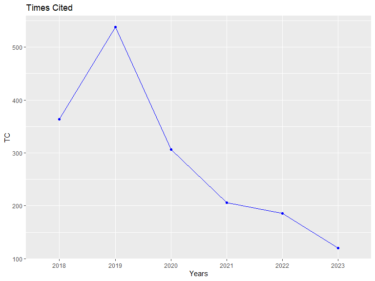

```r
plot(res2)
```

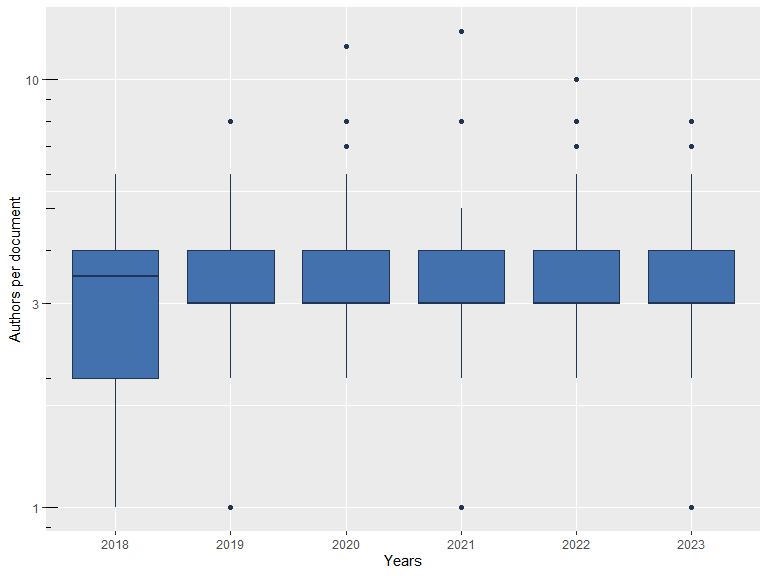

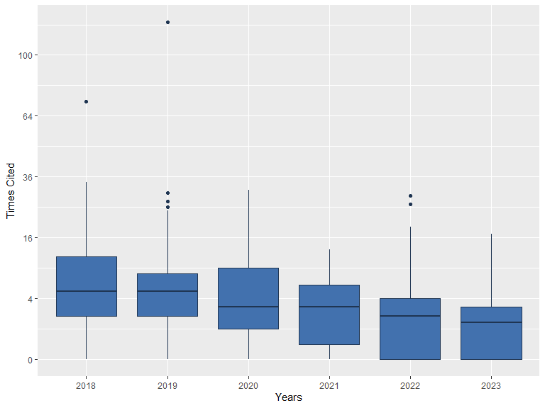

```r
plot(res2, boxplot = TRUE)
```

## Filtering

To filter elements (entities) of the database, you can use the functions `get_id_<table>()` to retrieve identification codes (IDs or entity key values). Any variable from the corresponding `<table>` may be used (multiple conditions are combined with `&`; see e.g. `dplyr::filter()`).

Typically, these functions are combined together with the `get_id_docs()` function to obtain document IDs, which are finally used in argument `filter` of summary functions to filter documents in results.

### Retrieving element IDs (entity key values)

- **`get_id_authors()`**: Retrieve author IDs (codes)

  Search for a specific author:

  ```r
  ida <- get_id_authors(db, AF == "Cao, Ricardo")
  ida
  ```

  ```
  ## Cao, Ricardo Cao, Ricardo
  ##           11          260
  ```

  Search by partial name match:

  ```r
  idas <- get_id_authors(db, grepl("Cao", AF))
  idas
  ```

  ```
  ##      Cao, Ricardo   Cao-Rial, M. T.      Cao, Ricardo           Cao, R.
  ##                11                80               260               328
  ## Cao Abad, Ricardo   Cao-Rial, M. T.
  ##               501               504
  ```

- **`get_id_areas()`**: Retrieve codes for research areas

  ```r
  get_id_areas(db, SC == "Mathematics")
  ```

  ```
  ## Mathematics
  ##          16
  ```

  ```r
  get_id_areas(db, SC == "Mathematics" | SC == "Computer Science")
  ```

  ```
  ## Computer Science      Mathematics
  ##                6               16
  ```

- **`get_id_categories()`**: Retrieve category codes

  ```r
  get_id_categories(db, grepl("Mathematics", WC))
  ```

  ```
  ##                                 Mathematics
  ##                                         148
  ##                        Mathematics, Applied
  ##                                         149
  ## Mathematics, Interdisciplinary Applications
  ##                                         150
  ```

- **`get_id_sources()`**: Retrieve source codes (journals, books, or collections)

  ```r
  idtest <- get_id_sources(db, SO == "TEST")
  idtest
  ```

  ```
  ## TEST
  ##    6
  ```

  ```r
  knitr::kable(t(db$Sources[idtest, ]),
    caption = "Test journal",
    col.names = c("Variable", "Value")
  )
  ```

  Test journal

  | Variable | Value |
  | --- | --- |
  | ids | 6 |
  | PT | Journal |
  | SO | TEST |
  | SE | NA |
  | BS | NA |
  | LA | English |
  | PU | SPRINGER |
  | PI | NEW YORK |
  | PA | ONE NEW YORK PLAZA, SUITE 4600, NEW YORK, NY, UNITED STATES |
  | SN | 1133-0686 |
  | EI | 1863-8260 |
  | BN | NA |
  | J9 | TEST-SPAIN |
  | JI | Test |

  ```r
  # get_id_sources(db, JI == 'Test')
  ```

### Retrieving documents IDs (by authors, journals, etc.)

The IDs retrieved above can be combined in `get_id_docs()`:

```r
idocs <- get_id_docs(db, id_authors = ida)
idocs
```

```
##  [1]   6  14  66  94 102 104 148 162 164 170 171 187 225 286 287 288
```

The document IDs can be used as filters, for example, in `summary.wos.db()`.

### Filtered Summaries

Get a summary for one or more authors:

```r
summary(db, idocs)
```

```
## Number of documents: 16
## Authors: 21
## Period: 2019 - 2023
##
## Document types:
##                    Documents
## Article                   10
## Editorial Material         5
## Review                     1
##
## Number of authors per document:
##    Min. 1st Qu.  Median    Mean 3rd Qu.    Max.
##    1.00    2.00    3.00    2.81    3.25    5.00
##
## Number of documents per author:
##    Min. 1st Qu.  Median    Mean 3rd Qu.    Max.
##    1.00    1.00    1.00    2.14    2.00    9.00
##
## Number of times cited:
##    Min. 1st Qu.  Median    Mean 3rd Qu.    Max.
##    0.00    0.00    2.50   11.81    6.75  123.00
##
## Indexes:
##  H  G
##  5 13
##
## Status:
## Highly Cited   Hot Papers
##            1            0
##
## Top Categories:
##                                                  Documents
## Statistics & Probability                                15
## Operations Research & Management Science                 2
## Computer Science, Interdisciplinary Applications         1
## Mathematical & Computational Biology                     1
## Mathematics                                              1
## Medical Informatics                                      1
## Medicine, Research & Experimental                        1
## Public, Environmental & Occupational Health              1
```

[output cut: 21 more lines]

```
## J. Stat. Comput. Simul.                       1
## Wiley Interdiscip. Rev.-Comput. Stat.         1
##
## Top Countries:
##             Documents
## Spain              16
## France              3
## Uruguay             2
## Belgium             1
## Canada              1
## Mexico              1
## Switzerland         1
## USA                 1
##
## International colaboration documents (Spain): 7
```

Get a year-by-year summary for one or more authors:

```r
summary_year(db, idocs)
```

```
## Annual Scientific Production:
##      Documents
## 2019         6
## 2020         2
## 2021         3
## 2022         3
## 2023         2
##
## Annual Authors per Document:
##    PY   Mean Median
##  2019 3.1667    3.5
##  2020 3.0000    3.0
##  2021 2.6667    3.0
##  2022 2.6667    3.0
##  2023 2.0000    2.0
##
## Annual Times Cited:
##    PY Cites   Mean Median
##  2019   166 27.667   10.5
##  2020    11  5.500    5.5
##  2021     6  2.000    0.0
##  2022     6  2.000    2.0
##  2023     0  0.000    0.0
##
## Status:
##    PY Highly Cited Hot Paper
##  2019            1         0
##  2020            0         0
##  2021            0         0
##  2022            0         0
##  2023            0         0
```

## Author metrics

Retrieve metrics for multiple authors:

```r
author_metrics(db, idas)
```

```
##                   H G
## Cao, Ricardo      3 9
## Cao-Rial, M. T.   4 5
## Cao, Ricardo      4 5
## Cao, R.           0 0
## Cao Abad, Ricardo 1 2
## Cao-Rial, M. T.   0 0
```

# Bibliographic database with JCR metrics

We can extends the bibliographic database by adding JCR metrics to sources, per year and WoS category.

## Import JCR data from WoS

Excel files with JCR data (avaliable from WoS) can be automatically loaded from a subdirectory:

```r
dir("JCR_download", pattern = "*.xlsx")
```

```
##  [1] "JCR_SCIE_2018.xlsx" "JCR_SCIE_2019.xlsx" "JCR_SCIE_2020.xlsx"
##  [4] "JCR_SCIE_2021.xlsx" "JCR_SCIE_2022.xlsx" "JCR_SCIE_2023.xlsx"
##  [7] "JCR_SSCI_2018.xlsx" "JCR_SSCI_2019.xlsx" "JCR_SSCI_2020.xlsx"
## [10] "JCR_SSCI_2021.xlsx" "JCR_SSCI_2022.xlsx" "JCR_SSCI_2023.xlsx"
```

To combine the files into a relational database, the `db_jcr()` function is used:

```r
jcr <- db_jcr("JCR_download")
```

## Add JCR data to a bibliographic database

The JCR data can be combined with a bibliographic database by using the `add_jcr()` function:

```r
dbjcr <- add_jcr(db, jcr)
```

Two additional tables, `JCRSour` and `JCRCatSour`, are added to the bibliographic database (the result is a `wos.jcr`-class S3 object).

The database resulting from this particular example is provided as a dataset of the `scimetr` package:

```r
names(dbjcr)
```

```
##  [1] "Docs"         "Authors"      "AutDoc"       "OI"           "OIDoc"
##  [6] "RI"           "RIDoc"        "Categories"   "CatSour"      "Areas"
## [11] "AreaSour"     "Addresses"    "AddAutDoc"    "Affiliations" "AffDoc"
## [16] "Sources"      "WSIndex"      "SourWSI"      "label"        "export.date"
## [21] "JCRSour"      "JCRCatSour"
```

```r
class(dbjcr)
```

```
## [1] "wos.jcr" "wos.db"
```

## Summaries

Auxiliary functions are available to perform database queries:

- **`get_jcr()`**: combines document indexes with their source JCR metrics per year.

  ```r
  head(get_jcr(dbjcr))
  ```

  ```
  ##   idd ids   PY   JIF   IMM  CHL   JIF5     JEF     JEFN   JAI
  ## 1   1   1 2021 1.673 0.165  4.9 11.808 0.01332  2.86423 4.500
  ## 2   2   2 2018 2.896 1.169  4.7  2.344 0.00585  0.69599 0.707
  ## 3   3   3 2023 2.300 0.900  1.9  2.200 0.03686  8.10075 0.374
  ## 4   4   4 2023 4.400 1.000  3.2  3.600 0.00847  1.86316 0.691
  ## 5   5   5 2023 4.400 1.000 10.0  7.600 0.12386 27.21696 3.056
  ## 6   6   6 2023 1.200 0.200  7.7  2.200 0.00235  0.51687 1.225
  ```

- **`get_jcr_cat()`** combines document indexes with their source JCR metrics per year and WoS category (if `best = TRUE`, only the results for the WoS category with the best ranking for each document are returned).

  ```r
  head(get_jcr_cat(dbjcr, best = TRUE))
  ```

  ```
  ##   idd ids   PY idc     WCR JIFQ   JIFP   WE WCP WCT
  ## 1   1   1 2021  46 0.13514   Q4 13.840 SCIE  97 112
  ## 2   2   2 2018  46 0.65714   Q2 65.566 SCIE  37 106
  ## 3   3   3 2023 148 0.95910   Q1 95.800 SCIE  21 490
  ## 4   4   4 2023  46 0.78107   Q1 77.900 SCIE  38 170
  ## 5   5   5 2023  26 0.78613   Q1 78.400 SCIE  38 174
  ## 6   6   6 2023 237 0.56287   Q2 56.300 SCIE  74 168
  ```

The summary methods combine the above queries and generate global summaries or yearly summaries of a bibliographic database with JCR metrics (if `all = TRUE`, the corresponding `wos.db`-class results are also generated).

```r
res1 <- summary(dbjcr)
res1
```

```
## JCR metrics:
##         JIF  IMM  CHL  JIF5     JEF   JEFN  JAI JIFP WCP
## Min.    0.4 0.00  1.1  0.48 0.00042  0.053 0.18  2.8   5
## 1st Qu. 1.0 0.26  5.6  1.00 0.00226  0.381 0.42 28.6  31
## Median  1.7 0.45  7.7  1.87 0.00500  0.848 0.66 56.3  58
## Mean    2.1 0.62  8.6  2.30 0.01119  2.060 0.83 55.1  86
## 3rd Qu. 2.6 0.83 10.4  2.73 0.01412  2.352 0.89 82.6 126
## Max.    9.7 2.69 39.5 11.81 0.20530 29.627 4.50 97.6 298
## NA's    1.0 1.00  1.0  2.00 1.00000  1.000 2.00  1.0   1
##
## Documents in JCR: 292 (99.66%)
## Documents in Q1: 90 (30.82% of JCR)
## Documents in D1: 50 (17.12% of JCR)
## Documents in top 3 journals: 0 (0% of JCR)
```

```r
res2 <- summary_year(dbjcr)
res2
```

```
## Mean of JCR metrics:
##    PY  JIF   IMM  CHL JIF5     JEF JEFN   JAI JIFP   WCP
##  2018 2.01 0.579 8.03 2.11 0.01397 1.66 0.864 54.8  89.7
##  2019 1.60 0.527 8.85 1.61 0.00876 1.07 0.605 49.3  78.4
##  2020 2.59 0.841 7.09 2.68 0.01030 2.16 0.899 60.8  87.2
##  2021 2.27 0.624 8.81 2.92 0.01108 2.38 1.068 53.7  73.5
##  2022 2.28 0.638 8.98 2.39 0.01050 2.29 0.769 55.3  85.2
##  2023 1.98 0.520 9.38 2.21 0.01349 2.97 0.830 58.4 103.7
##
## Documents in JCR:
## 2018 2019 2020 2021 2022 2023
##   40   61   45   51   45   50
##
## Documents in Q1:
## 2018 2019 2020 2021 2022 2023
##   13   13   19   15   13   17
##
## Documents in D1:
## 2018 2019 2020 2021 2022 2023
##    6    5   15    8    7    9
##
## Documents in top 3 journals:
## 2018 2019 2020 2021 2022 2023
##    0    0    0    0    0    0
```

Note: `res1$docjcrcat` contains the combined queries.

## Visualizations

The `plot()` method (`plot.wos.jcr()`) generates histograms of documents JCR metrics (if argument `all = TRUE`, `plot.wos.bd()` is also called):

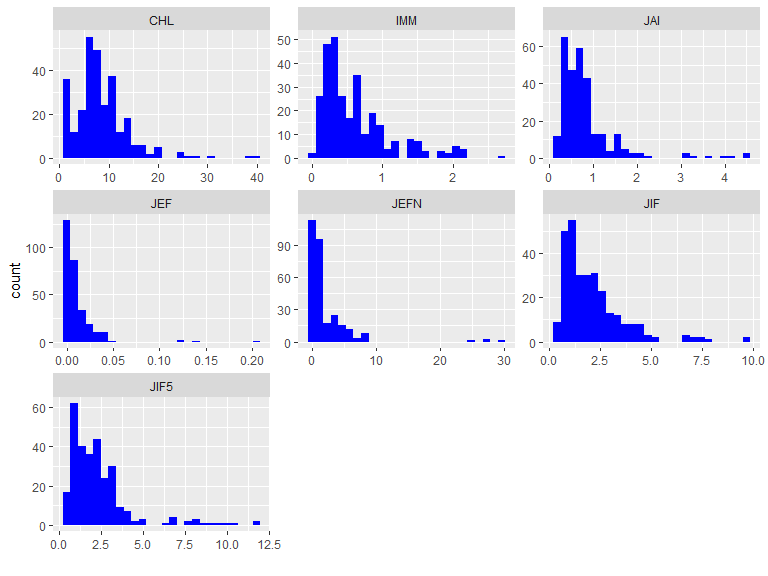

```r
plot(dbjcr)
```

Summary results have also a `plot()` method:

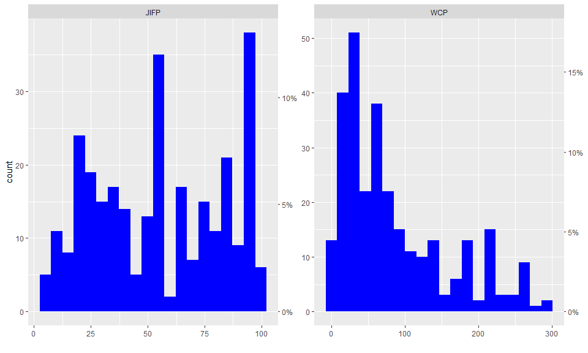

```r
plot(res1)
```

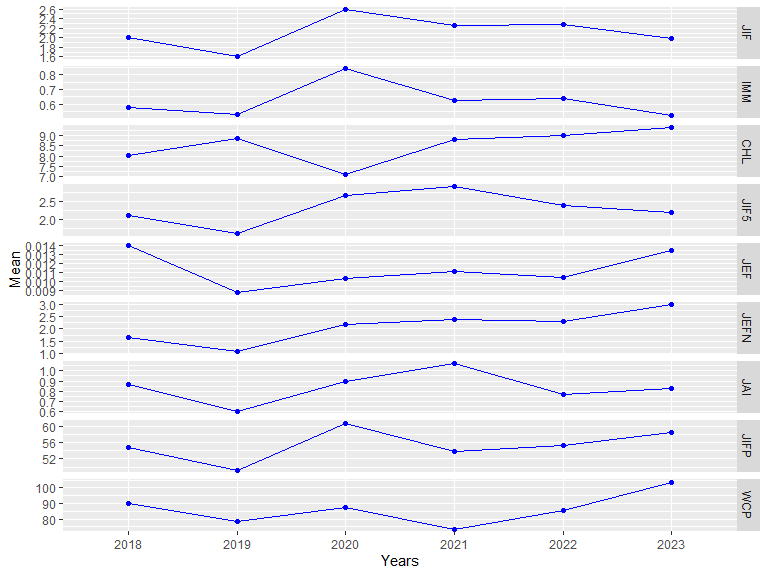

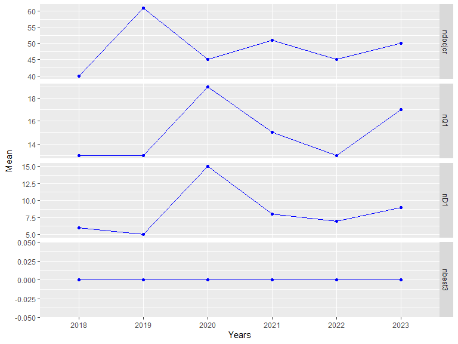

```r
plot(res2)
```

# Variable list

The following list shows all variables used in the database tables:

| Variable | Label |
| --- | --- |
| AF | Author Full Name |
| AFOI | ORCID Full Name |
| AFRI | RI Full Name |
| an | Number of authors |
| AR | Article Number |
| AU | Author |
| BN | ISBN |
| BP | Start Page |
| BS | Book Series Subtitle |
| C1 | Address |

[output cut: 66 more lines]

Note: The table above was generated using the `datatable()` function from the [DT](https://rstudio.github.io/DT/) package. By default, the first rows are displayed. Click on the page index (below) to change this. You can sort by column by clicking on the arrows to the right of its name. You can search for values (search box, top right) and filter values (click on the filter box below the name of each variable).